# Project-RW

# Multivariate Analysis

### Talk about some of the relationships you observed in this part of the investigation. Were there features that strengthened each other in terms of looking at your feature(s) of interest?

Good wines concentrate when citric acid is more than 0.3 and alcohol is more than 10.5 and also when citric acid is above 0.27 g/dm<sup>3</sup> and volatile acidity is below 0.5 g/dm<sup>3</sup>.

Following things were also observed:

- Mean and median of alcohol seems to be more for quality of 7 and 8.
- Mean and median of volatile acidity seems to be more for quality levels of 3 and 4.
- Mean and median of fixed acidity seems to be more for quality levels of 7 and 8.

### Were there any interesting or surprising interactions between features?

Something interesting interaction is observed, good wines concentrate when citric acid is more than 0.3 and alcohol is more than 10.5. That is, when we have certain levels of both then we have a more high quality scores.

## Final Plots and Summary

### Plot 1

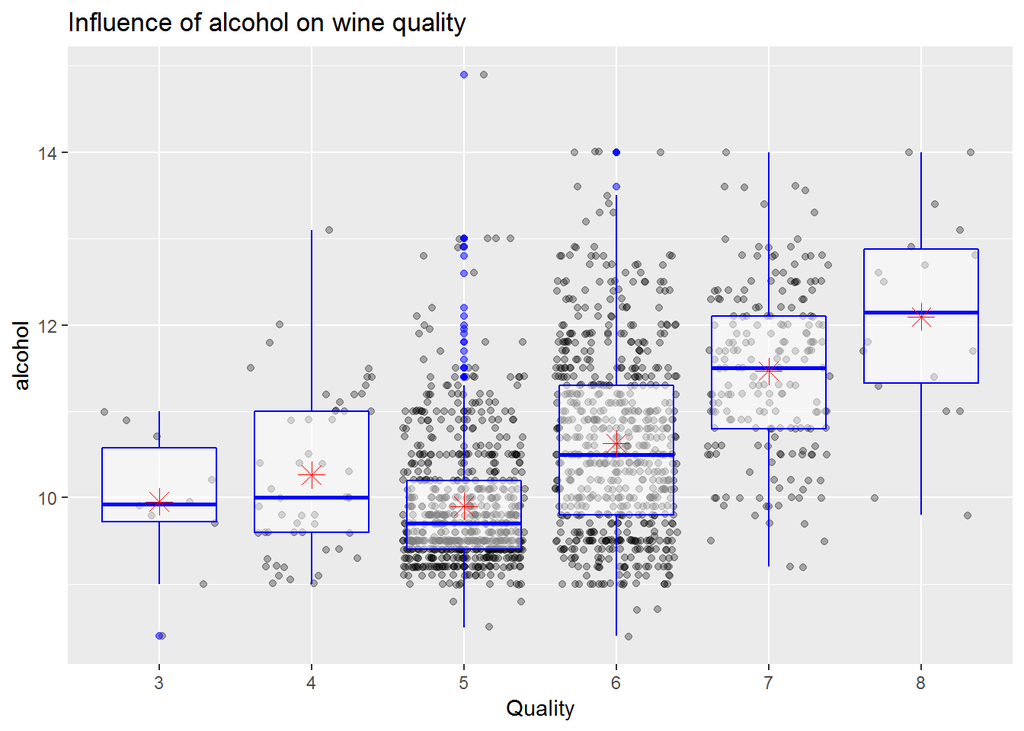

### Plot 2

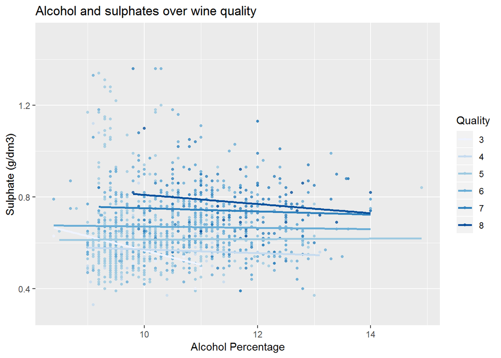

In this plot, we see that the best quality wines have high values for both Alcohol percentage and Sulphate concentration implying that High alcohol contents and high sulphate concentrations together seem to produce better wines. Although there is a very slight downwards slope maybe because in best quality wines, percentage of alcohol is slightly greater than the concentration of Sulphates.

### Plot 3

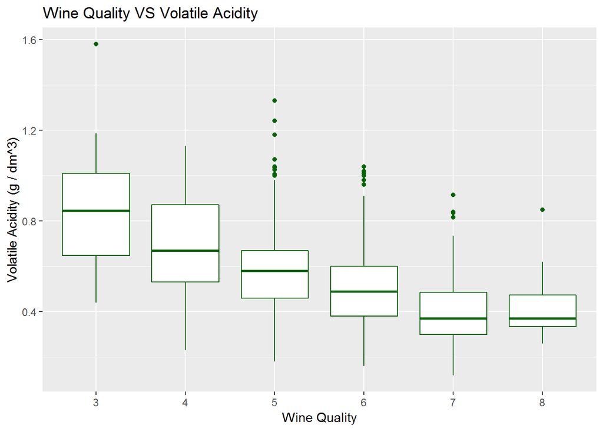

# Reflection

The data set contains information on almost 1599 wine sampels across 14. In initial phase, I started understanding individual variables(univariate analysis), from which I explored interesting questions and made observations. Then I explored quality of wine accross mltiple variables (bivariate analysis and multivariate analysis)

The analysis performed on the sample dataset can be summarised as below:

pH value is considered an important parameter when determining the quality of the Wine.These pH value however was found to be optimum between a value of 3.0 and 3.5 .A pH value of higher than 3.5 tends to exhibit a higher sulphate values.

Some of the learnings from the analysis were as follows:

- The understanding that Red Wine generally exhibits more sulfur dioxide properties. *It always seemed that pH value was a key factor in detemining the quality of the wines but from the analysis ,it seems that pH value do not exhibit any patterns which can be utilized for determination of wine quality.
- From the samples analyzed,the wines with higher Alcohol content exhibited lower Sulfue dioxide content as compared with samples with lower Alcohol content.

A limitation of the current analysis is that the current data consists of samples collected from a specific region and the data is old. It would be great if we can get a big and recent data set from different regions of world. I would also like to construct linear models for prediction of wine quality and to calculate the accuracy of model.s.

# References

- Most of my code is what is learn in the Udacity classroom.
- https://www.r-bloggers.com/
- https://stackoverflow.com/
- https://www.guru99.com/r